# Lab 10 - Vanilla CNN and Fine-Tune VGG16 - for Dogs and Cats Classification

### Precision Recall Curve for model 2

```python
precision, recall, thresholds = precision_recall_curve(test_labels, y_test_pred.flatten())
```

```python
threshold = 0.8
```

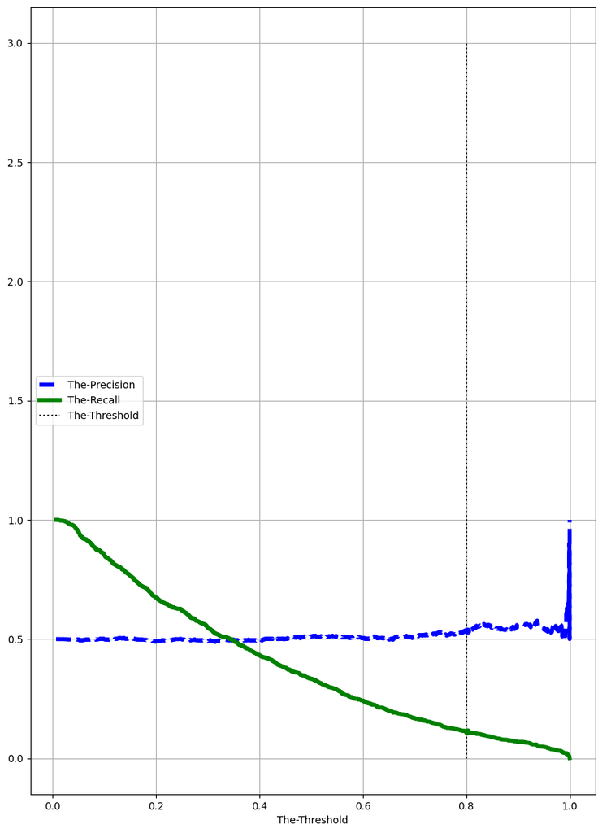

```python
# Plot Precision-Recall curve with customized style
plt.plot(thresholds, precision[:-1], "b--", label="The-Precision", linewidth=4)  # Plot Precision
plt.plot(thresholds, recall[:-1], "g-", label="The-Recall", linewidth=4)  # Plot Recall

# Highlight the selected threshold
plt.vlines(threshold, 0, 3.0, "k", linestyle="dotted", label="The-Threshold")  # Vertical line at threshold
idx = (thresholds >= threshold).argmax()  # Find index where threshold is located
plt.plot(thresholds[idx], precision[idx], "bo")  # Plot precision at selected threshold
plt.plot(thresholds[idx], recall[idx], "go")  # Plot recall at selected threshold

# Set labels, legend, and grid
plt.xlabel("The-Threshold")
plt.legend(loc="center left")
plt.grid(True)

# Show the plot
plt.show()
```

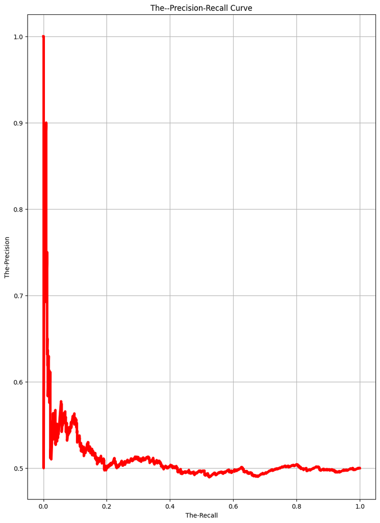

```python
# Plot Precision-Recall curve with customized style
plt.plot(recall, precision, "r-", linewidth=4)  # Plot Precision-Recall curve with red color and increased line width

# Set labels, title, and grid
plt.xlabel("The-Recall")
plt.ylabel("The-Precision")
plt.title('The--Precision-Recall Curve')
plt.grid(True)

# Show the plot
plt.show()
```

```python
# Create a DataFrame to display model predictions
predictions_df = pd.DataFrame({
    'Probability': y_test_pred.flatten().round(5),  # Include predicted probabilities rounded to 6 decimal places
    'Predicted_Class': y_test_pred_binary,  # Include predicted classes
    'Ground_Truth': test_labels  # Include ground truth labels
})

# Display the DataFrame
display(predictions_df)
```

|  | Probability | Predicted_Class | Ground_Truth |
| --- | --- | --- | --- |
| 0 | 0.81202 | 1 | 1 |
| 1 | 0.15965 | 0 | 1 |
| 2 | 0.31471 | 0 | 1 |
| 3 | 0.26611 | 0 | 0 |
| 4 | 0.59749 | 0 | 0 |
| ... | ... | ... | ... |
| 1995 | 0.36308 | 0 | 0 |
| 1996 | 0.58068 | 0 | 1 |
| 1997 | 0.76348 | 1 | 0 |
| 1998 | 0.11543 | 0 | 0 |
| 1999 | 0.05266 | 0 | 1 |

2000 rows × 3 columns

```python
# Filter rows where predicted class does not match ground truth
mismatch_df = predictions_df[predictions_df['Predicted_Class'] != predictions_df['Ground_Truth']]

# Display the mismatched DataFrame
display(mismatch_df)
```

|  | Probability | Predicted_Class | Ground_Truth |
| --- | --- | --- | --- |
| 1 | 0.15965 | 0 | 1 |
| 2 | 0.31471 | 0 | 1 |
| 8 | 0.99929 | 1 | 0 |
| 12 | 0.35893 | 0 | 1 |
| 13 | 0.09956 | 0 | 1 |
| ... | ... | ... | ... |
| 1992 | 0.88497 | 1 | 0 |
| 1994 | 0.05504 | 0 | 1 |
| 1996 | 0.58068 | 0 | 1 |
| 1997 | 0.76348 | 1 | 0 |
| 1999 | 0.05266 | 0 | 1 |

993 rows × 3 columns

```python
# Get the indices of mismatched predictions
mismatch_indices = mismatch_df.index.tolist()

# Calculate the number of mismatched instances
num_mismatches = len(mismatch_indices)
num_mismatches
```

```
993
```

In machine learning, especially in the context of classification tasks, a "mismatch" typically refers to instances where the model's predicted class label does not match the ground truth label of the corresponding data point. These instances are often of interest because they represent cases where the model may have made errors.

When analyzing mismatched instances, it's essential to understand why the model made incorrect predictions. This analysis can provide insights into the limitations of the model and suggest areas for improvement. Here's a brief outline of the steps involved in analyzing mismatched instances:

Identification: Determine which instances in the dataset have mismatched predictions. This involves comparing the predicted class labels generated by the model with the true class labels (ground truth).

Quantification: Calculate the number of mismatched instances. This metric gives a sense of the extent of the model's errors and helps prioritize further analysis.

Visualization: Visualize the mismatched instances to gain insights into patterns or trends. Techniques such as confusion matrices, precision-recall curves, or scatter plots can help visualize the distribution of errors across different classes or feature dimensions.

Error Analysis: Dive deeper into the characteristics of mismatched instances to understand why the model failed to make correct predictions. This analysis may involve examining features, model predictions, and ground truth labels to identify common patterns or sources of confusion.

Model Improvement: Based on the insights gained from error analysis, make adjustments to the model architecture, training process, or feature representation to address the identified shortcomings and improve overall performance.

By systematically analyzing mismatched instances, machine learning practitioners can iteratively refine their models and develop more accurate and reliable systems for real-world applications.

```python
def visualize_mismatches(dataset, mismatch_indices, max_images=20):
    # Initialize counters
    count, img_count = 0, 0
    for images, labels in dataset.unbatch().batch(1):  # Iterate over individual images
        if count in mismatch_indices:  # Check if the current image is a mismatch
            plt.figure(figsize=(12, 12))
            plt.imshow(images[0].numpy().astype("uint8"))
            plt.title(f'Index: {count}')
            plt.axis('off')
            plt.show()

            img_count += 1
            if img_count >= max_images:
                break
        count += 1  # Increment the counter
```

The provided function visualize_mismatches is designed to visualize a subset of mismatched images from a given dataset based on their indices in the dataset. Here's a breakdown of how the function works:

Input Parameters:

The function iterates over the images in the dataset one by one using the unbatch().batch(1) method. This allows it to access individual images. For each image, it checks if its index (count) is present in the mismatch_indices. If the index corresponds to a mismatched image, it visualizes the image using Matplotlib, along with its index as the title. It keeps track of the number of mismatched images visualized (img_count) and stops when it reaches max_images. Visualization:

Each mismatched image is displayed as a separate plot with its index as the title. The images are displayed using Matplotlib's imshow function, with the axis turned off to remove axes labels. Control Flow:

The function terminates if it has visualized the specified number of mismatched images (max_images). It also ensures that the loop terminates when all mismatched images have been visualized. Overall, this function provides a convenient way to visualize a subset of mismatched images from a dataset, aiding in the analysis of model errors and potential insights for improvement.

### Conclusions

After successfully training and evaluating two models, one built from scratch (referred to as the vanilla model) and the other a fine-tuned VGG16 model, we observed an interesting phenomenon in their performance.

Further analysis could involve investigating the specific characteristics of the dataset, the model architectures, and the training process to understand the factors contributing to the observed performance differences between the vanilla and fine-tuned VGG16 models.